# An Introduction to ggplot2 Part Two: Legends

Jeff Atkins

October 24, 2017

- For everything in this section, and for a lot of things moving forward, I have always found the [R Graphics Cookbook from Winston Chang](http://www.cookbook-r.com/Graphs/) to be invaluable. Most things are online, but buy it if ya can.

#### Begin by Initating ggplot2

## Legends

You have already succesfully made some pretty amazing plots using the `iris` dataset. Now it is time we really make them our own. One of the great things about ggplot2 (and R too) is not only can we express our data in a clear and concise manner, we can also personalize and customize those plots. Here is our plot from earlier:

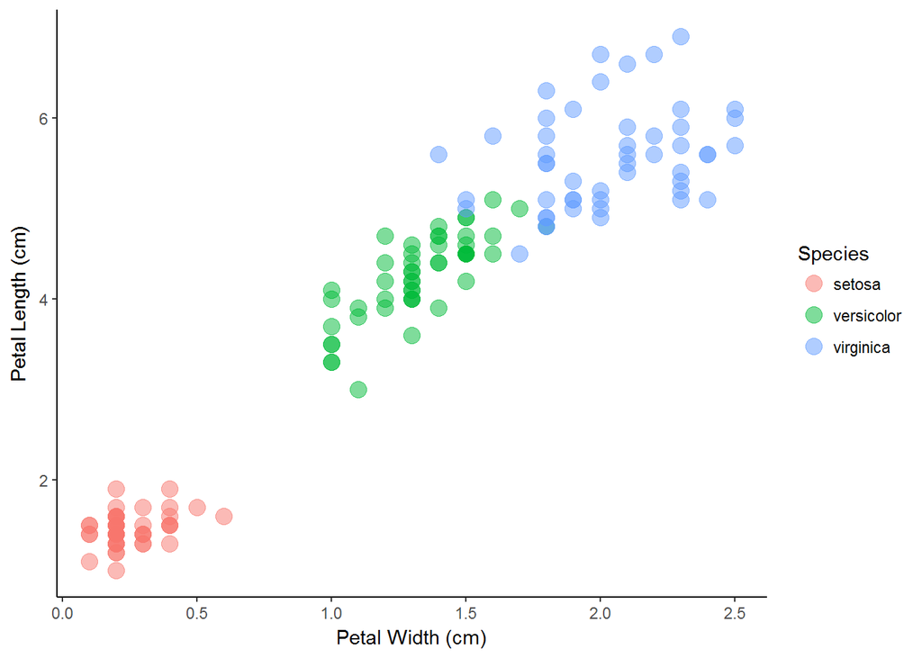

```r
ggplot(iris, aes(x = Petal.Width, y = Petal.Length, color = Species))+
  geom_point(size = 4, alpha = 0.5)+
  xlab("Petal Width (cm)")+
  ylab("Petal Length (cm)")+
  theme_classic()
```

Not a fan of a legend to the side? No problem. If you use the very powerful `theme()` code, you can do some cool stuff.

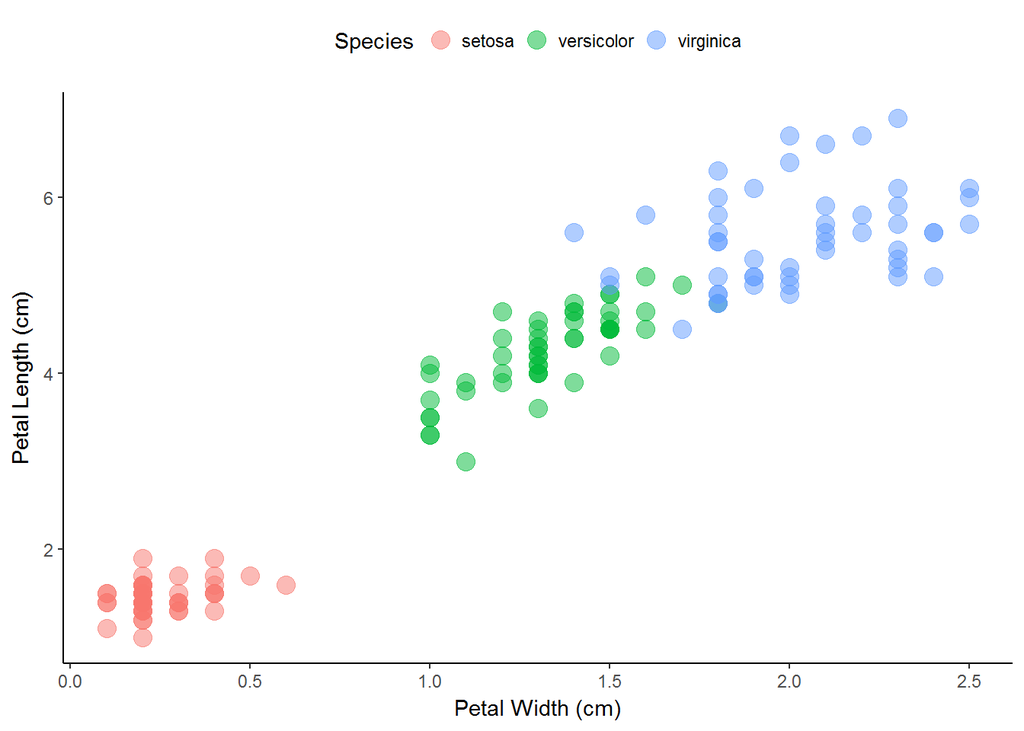

```r
ggplot(iris, aes(x = Petal.Width, y = Petal.Length, color = Species))+
  geom_point(size = 4, alpha = 0.5)+
  xlab("Petal Width (cm)")+
  ylab("Petal Length (cm)")+
  theme_classic()+
  theme(legend.position = "top")
```

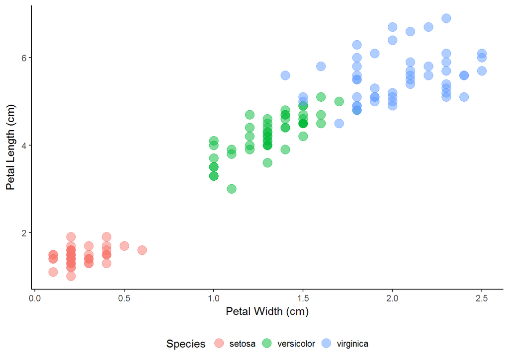

```r
ggplot(iris, aes(x = Petal.Width, y = Petal.Length, color = Species))+
  geom_point(size = 4, alpha = 0.5)+
  xlab("Petal Width (cm)")+
  ylab("Petal Length (cm)")+
  theme_classic()+
  theme(legend.position = "bottom")
```

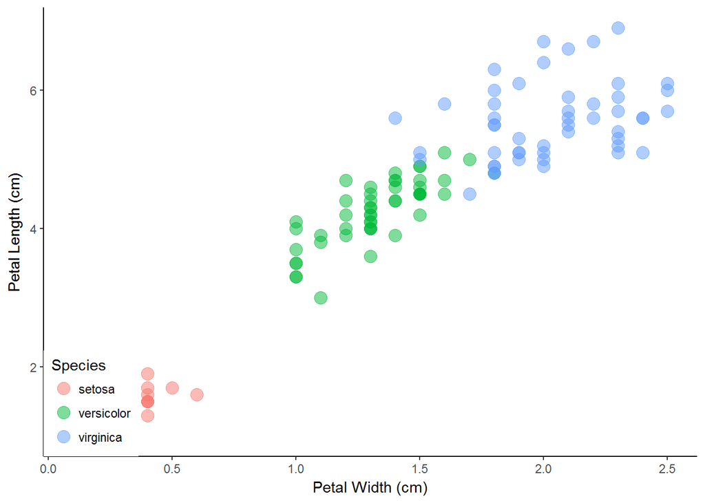

```r
ggplot(iris, aes(x = Petal.Width, y = Petal.Length, color = Species))+
  geom_point(size = 4, alpha = 0.5)+
  xlab("Petal Width (cm)")+
  ylab("Petal Length (cm)")+
  theme_classic()+
  theme(legend.justification=c(0,0), legend.position=c(0,0)) # Put bottom-left corner of legend box in bottom-left corner of graph
```

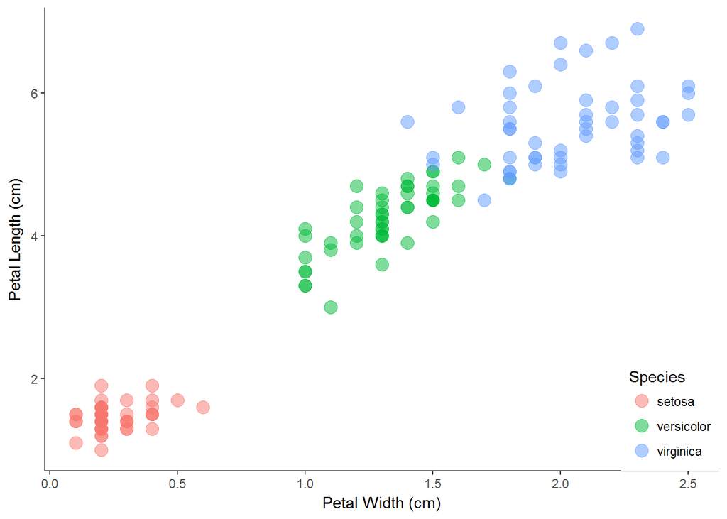

```r
ggplot(iris, aes(x = Petal.Width, y = Petal.Length, color = Species))+
  geom_point(size = 4, alpha = 0.5)+
  xlab("Petal Width (cm)")+
  ylab("Petal Length (cm)")+
  theme_classic()+
 theme(legend.justification=c(1,0), legend.position=c(1,0)) # Put bottom-right corner of legend box in bottom-right corner of graph
```

But wait, there’s more! We can change around what our legend looks like and even change the color scheme of our data

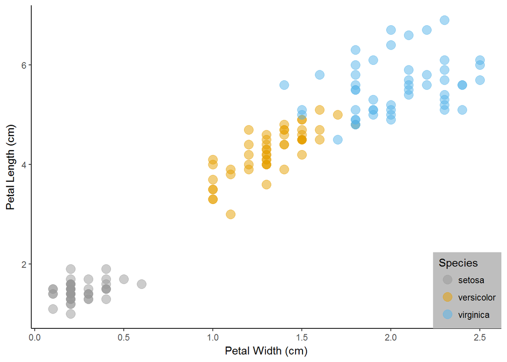

```r
ggplot(iris, aes(x = Petal.Width, y = Petal.Length, color = Species))+
  geom_point(size = 4, alpha = 0.5)+
  xlab("Petal Width (cm)")+
  ylab("Petal Length (cm)")+
  theme_classic()+
  scale_color_manual(values=c("#999999", "#E69F00", "#56B4E9"))+
 theme(legend.justification=c(1,0),
       legend.position=c(1,0),
       legend.background = element_rect(fill="grey"))
```

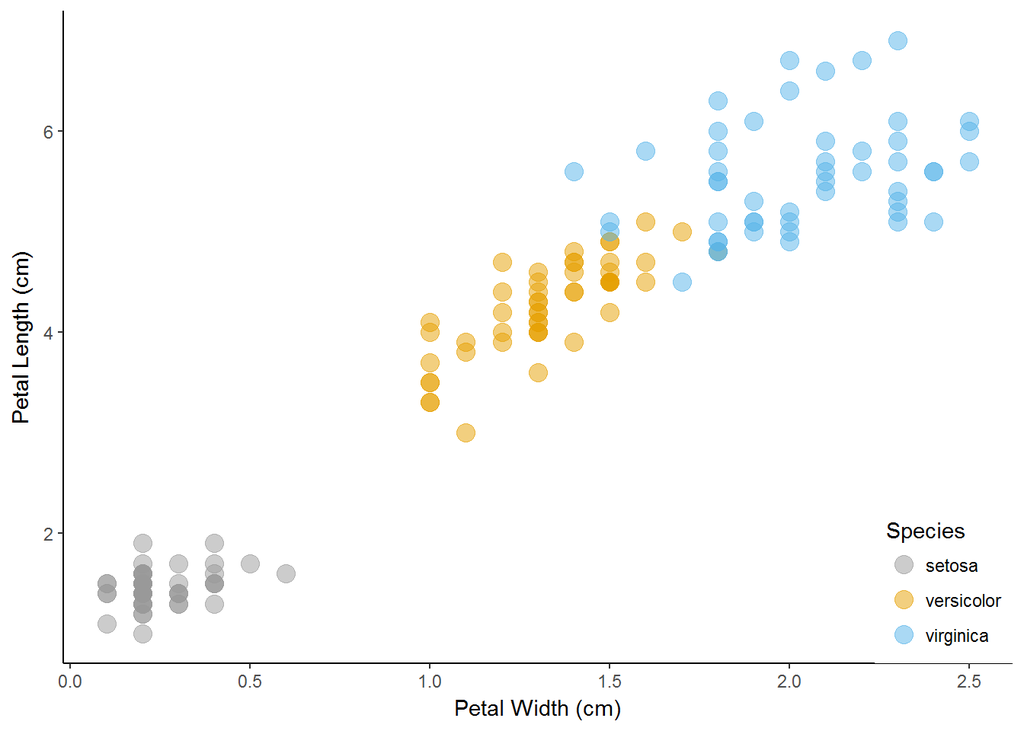

```r
ggplot(iris, aes(x = Petal.Width, y = Petal.Length, color = Species))+
  geom_point(size = 4, alpha = 0.5)+
  xlab("Petal Width (cm)")+
  ylab("Petal Length (cm)")+
  theme_classic()+
  scale_color_manual(values=c("#999999", "#E69F00", "#56B4E9"),
                       name="Species",
                       breaks=c("setosa", "versicolor", "virginica"),
                       labels=c("setosa", "versicolor", "virginica"))+
 theme(legend.justification=c(1,0),
       legend.position=c(1,0))
```

#### Challenge!

With all of this new found knowledge, using the `iris` dataset, I want you to produce the ugliest plot you can.